# Project 1: Wrangling, Exploration, Visualization

SDS322E

## Data Wrangling, Exploration, Visualization

### Wesley Lu, wl8838

#### Introduction

Humans inhale oxygen and exhale carbon dioxide as a waste product. An excessive level of carbon dioxide in the air could lead to insufficient oxygen and imbalanced pH levels in blood. Additionally, an increase in CO2, a greenhouse gas, can lead to a phenomenon called the greenhouse effect where less heat escapes from the surface of the Earth, causing graduate warming of Earth’s climate system. This warming could have dramatic impacts on ecosystems in ways not foreseeable by humans, but ultimately could have a lasting impact on our global health. The goal of using these two datasets is to see if there is any correlation between the levels of carbon dioxide and global health.

```r
# read your datasets in here, e.g., with read_csv()
library(tidyverse)
library(gt)
CO2 <- read_csv("CO2_Emissions_1960-2018.csv")
health <- read_csv("country_health_indicators_v3.csv")
```

#### Tidying: Reshaping

If your datasets are tidy already, demonstrate that you can reshape data with pivot wider/longer here (e.g., untidy and then retidy). Alternatively, it may be easier to wait until the wrangling section so you can reshape your summary statistics. Note here if you are going to do this.

```r
# your tidying code (if applicable; can also wait until
# wrangling section)

# untidy and then retidy
CO2 <- CO2 %>% pivot_longer(cols = 2:60, names_to = "Year", values_to = "Emissions",
    values_drop_na = T)
CO2 <- CO2 %>% pivot_wider(names_from = "Year", values_from = "Emissions")
```

`CO2` is tidied by listing years into one column, but untied years back to columns because data from `health` are all collected in a single year.

#### Joining/Merging

```r
# your joining code
data <- CO2 %>% inner_join(health, by = c(`Country Name` = "Country_Region"))
data %>% summarize(n_distinct(`Country Name`))
```

```
## # A tibble: 1 x 1
##   `n_distinct(\`Country Name\`)`
##                            <int>
## 1                            152
```

The common ID of these two datasets is country; however, some countries exist in one dataset and not the other. Inner join is therefore selected as the joining method to ensure that there are valid values for both emissions and health indicators for all countries after joining. There are 152 IDs that both the dataset have in common.

```r
# your joining code
CO2 %>% nrow()
```

```
## [1] 250
```

```r
CO2 %>% summarize(n_distinct(`Country Name`))
```

```
## # A tibble: 1 x 1
##   `n_distinct(\`Country Name\`)`
##                            <int>
## 1                            250
```

```r
health %>% nrow()
```

```
## [1] 180
```

```r
health %>% summarize(n_distinct(Country_Region))
```

```
## # A tibble: 1 x 1
##   `n_distinct(Country_Region)`
##                          <int>
## 1                          180
```

There are 250 and 180 observations in `CO2` and `health` respectively. As such, both of the original datasets have more observations than the joined dataset. There are 250 and 180 distinct IDs in `CO2` and `health` respectively.

```r
unique_CO2 <- CO2 %>% anti_join(health, by = c(`Country Name` = "Country_Region"))
unique_health <- health %>% anti_join(CO2, by = c(Country_Region = "Country Name"))

unique_CO2 %>% summarize(n_distinct(`Country Name`))
```

```
## # A tibble: 1 x 1
##   `n_distinct(\`Country Name\`)`
##                            <int>
## 1                             98
```

```r
unique_health %>% summarize(n_distinct(Country_Region))
```

```
## # A tibble: 1 x 1
##   `n_distinct(Country_Region)`
##                          <int>
## 1                           28
```

There are 98 IDs appeared in `CO2` but not in `health` and 28 IDs appared in `health` but not in `CO2`.

```r
unique_CO2 %>% nrow()
```

```
## [1] 98
```

```r
unique_health %>% nrow()
```

```
## [1] 28
```

98 and 28 observations in `CO2` and `health` were dropped after joining respectively.

#### Wrangling

```r
# your wrangling code
better_data <- data %>% rename(Country = `Country Name`, Emissions = `2018`) %>%
    select(Country, Emissions, `Cardiovascular diseases (%)`:`Nutritional deficiencies (%)`)
better_data <- better_data %>% mutate(`Emissions>50` = case_when(Emissions >=
    median(Emissions) ~ "True", Emissions < median(Emissions) ~
    "False"))
```

I renamed two column names and selected 10 variables of interest for the final dataset. Additionally, I generated a variable as a function of `Emissions` to give insight on `Emissions` relating to various diseases in later use.

```r
# your wrangling code
better_data %>% summarize_all(function(x) sum(is.na(x)))
```

```
## # A tibble: 1 x 13
##   Country Emissions `Cardiovascular… `Cancers (%)` `Diabetes, bloo…
##     <int>     <int>            <int>         <int>            <int>
## 1       0         0                4             4                4
## # … with 8 more variables: `Respiratory diseases (%)` <int>, `Liver disease
## #   (%)` <int>, `Diarrhea & common infectious diseases (%)` <int>,
## #   `Musculoskeletal disorders (%)` <int>, `HIV/AIDS and tuberculosis
## #   (%)` <int>, `Malaria & neglected tropical diseases (%)` <int>, `Nutritional
## #   deficiencies (%)` <int>, `Emissions>50` <int>
```

```r
better_data %>% transmute(str_replace(`Emissions>50`, "^.", tolower))
```

```
## # A tibble: 152 x 1
##    `str_replace(\`Emissions>50\`, "^.", tolower)`
##    <chr>
##  1 false
##  2 false
##  3 false
##  4 true
##  5 true
##  6 true
##  7 false
##  8 true
##  9 true
## 10 true
## # … with 142 more rows
```

```r
better_data %>% group_by(Country) %>% summarize(n())
```

```
## # A tibble: 152 x 2
##    Country             `n()`
##    <chr>               <int>
##  1 Afghanistan             1
##  2 Albania                 1
##  3 Algeria                 1
##  4 Andorra                 1
##  5 Angola                  1
##  6 Antigua and Barbuda     1
##  7 Argentina               1
##  8 Armenia                 1
##  9 Australia               1
## 10 Austria                 1
## # … with 142 more rows
```

```r
better_data %>% group_by(`Emissions>50`) %>% summarize(n())
```

```
## # A tibble: 2 x 2
##   `Emissions>50` `n()`
##   <chr>          <int>
## 1 False             76
## 2 True              76
```

```r
better_data %>% group_by(Country, `Emissions>50`) %>% summarize_all(n_distinct,
    na.rm = T)
```

```
## # A tibble: 152 x 13
## # Groups:   Country [152]
##    Country `Emissions>50` Emissions `Cardiovascular… `Cancers (%)`
##    <chr>   <chr>              <int>            <int>         <int>
##  1 Afghan… False                  1                1             1
##  2 Albania False                  1                1             1
##  3 Algeria True                   1                1             1
##  4 Andorra True                   1                1             1
##  5 Angola  False                  1                1             1
##  6 Antigu… True                   1                1             1
##  7 Argent… True                   1                1             1
##  8 Armenia False                  1                1             1
##  9 Austra… True                   1                1             1
## 10 Austria True                   1                1             1
## # … with 142 more rows, and 8 more variables: `Diabetes, blood, & endocrine
## #   diseases (%)` <int>, `Respiratory diseases (%)` <int>, `Liver disease
## #   (%)` <int>, `Diarrhea & common infectious diseases (%)` <int>,
## #   `Musculoskeletal disorders (%)` <int>, `HIV/AIDS and tuberculosis
## #   (%)` <int>, `Malaria & neglected tropical diseases (%)` <int>, `Nutritional
## #   deficiencies (%)` <int>
```

```r
better_data %>% arrange(desc(Emissions)) %>% filter(`Cardiovascular diseases (%)` >
    median(`Cardiovascular diseases (%)`, na.rm = T))
```

```
## # A tibble: 74 x 13
##    Country Emissions `Cardiovascular… `Cancers (%)` `Diabetes, bloo…
##    <chr>       <dbl>            <dbl>         <dbl>            <dbl>
##  1 Canada      15.5              13.7         18.3              6.38
##  2 Luxemb…     15.3              14.2         17.7              5.32
##  3 Oman        15.2              13.6          4.73             9.95
##  4 Trinid…     12.8              18.3         10.2             16.9
##  5 Estonia     12.1              25.4         15.8              4.96
##  6 Kazakh…     12.1              25.6          8.97             4.10
##  7 Libya        8.83             16.9          8.71             8.45
##  8 Japan        8.74             14.8         19.2              6.47
##  9 Germany      8.56             19.0         18.8              6.19
## 10 Singap…      8.40             14.1         13.3              6.55
## # … with 64 more rows, and 8 more variables: `Respiratory diseases (%)` <dbl>,
## #   `Liver disease (%)` <dbl>, `Diarrhea & common infectious diseases
## #   (%)` <dbl>, `Musculoskeletal disorders (%)` <dbl>, `HIV/AIDS and
## #   tuberculosis (%)` <dbl>, `Malaria & neglected tropical diseases (%)` <dbl>,
## #   `Nutritional deficiencies (%)` <dbl>, `Emissions>50` <chr>
```

I wrote a function to calculate the number of missing values for all variables. I performed a stringr function to lowercase the first letter of the `Emissions>50` column. I calculated the counts of each level for categorical variable `Country` and `Emissions>50`. Grouping `Country` and `Emissions>50` simultaneously, I found the number of distinct values in each column. Lastly, I generated a table with countries that are more likely getting a cardiovascular disease, viewing by descending `Emissions`.

```r
# your wrangling code
table1 <- better_data %>% group_by(`Emissions>50`) %>% summarize_at(c(2:12),
    .funs = list(mean = mean, sd = sd, min = min, max = max),
    na.rm = T) %>% pivot_longer(-1) %>% separate(name, into = c("name",
    "stat"), sep = "_") %>% pivot_wider()

table1 %>% gt %>% tab_header(title = md("**Summary Statistics**"),
    subtitle = md("A table of my summary statistics")) %>% tab_spanner(label = "Variables",
    columns = c("Emissions"))
```

**Summary Statistics**

A table of my summary statistics

[output not shown]

Grouping by `Emissions>50`, I calculated the mean, standard deviation, minimum, and maximum of the percent getting the selected 10 diseases. The result is reorganized in an easier-to-read table using the `gt` package. Interestingly, the spread of non-contagious diseases seems to have an increase when CO2 emission increases, but contagious diseases seem to fall down when CO2 emission increases. However, there are too many confounding factors to come to any conclusive findings.

#### Visualizing

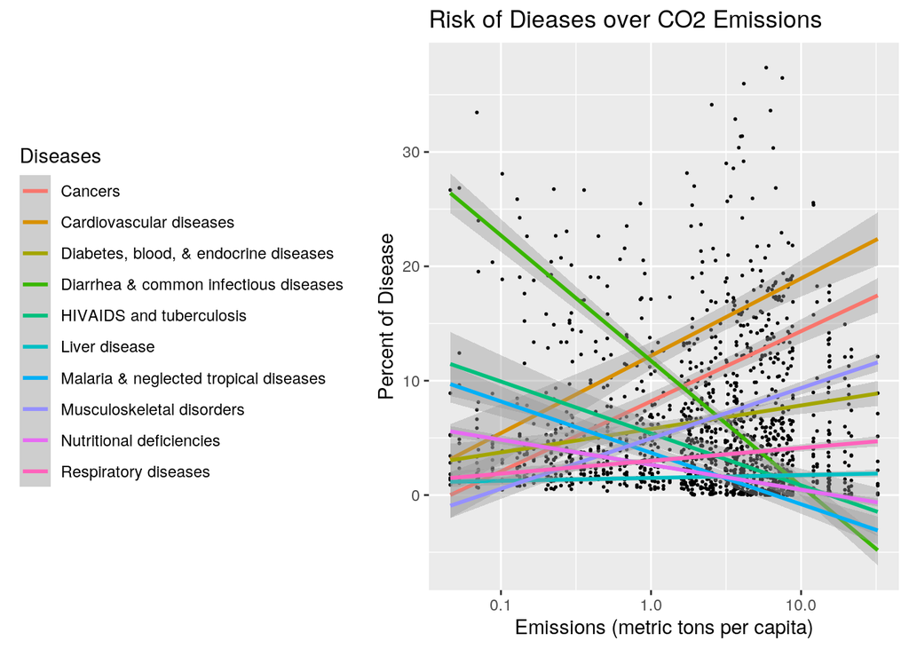

```r
# your plot 1
long <- better_data %>% pivot_longer(cols = 3:12, names_to = "Diseases",
    values_to = "Percent", values_drop_na = T) %>% mutate(Diseases = str_remove_all(Diseases,
    "[(/%)]"))

long %>% ggplot(aes(Emissions, Percent)) + geom_point(size = 0.3) +
    labs(x = "Emissions (metric tons per capita)", y = "Percent of Disease",
        title = "Risk of Dieases over CO2 Emissions") + geom_smooth(method = "lm",
    aes(color = Diseases)) + theme(legend.position = "left") +
    scale_x_continuous(breaks = seq(0, 40, 5)) + scale_x_log10()
```

This scatterplot depicts the relationship between `Emissions` and various diseases. As shown, about 50% of the diseases show a positive relationship with CO2 emissions while the other 50% show a negative relationship. Ones with a negative relationship are more likely to be infectious and transmittable diseases.

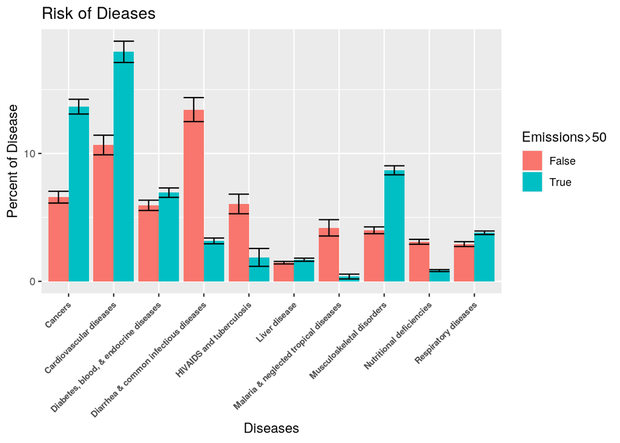

```r
# your plot 2
long %>% ggplot(aes(x = Diseases, y = Percent, fill = `Emissions>50`)) +
    geom_bar(stat = "summary", fun = mean, position = "dodge") +
    geom_errorbar(stat = "summary", fun.data = mean_se, position = "dodge") +
    theme(axis.text.x = element_text(angle = 45, vjust = 1, hjust = 1,
        size = 7, face = "bold")) + labs(y = "Percent of Disease",
    title = "Risk of Dieases") + scale_y_continuous(n.breaks = 4)
```

This grouped bar graph compares the mean percent of a disease in which emissions are greater and less than the median emissions. The resulting diagram shows a similar relationship as the last graph. About 50% of diseases are more likely to occur when the CO2 emissions is greater than the median emissions, and the other 50% are more likely to occur when the CO2 emissions is less than the median emissions.

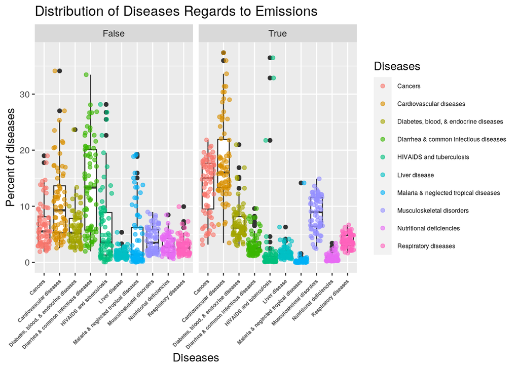

```r
# your plot 3
long %>% ggplot(aes(x = Diseases, y = Percent)) + geom_boxplot() +
    geom_jitter(alpha = 0.6, aes(color = Diseases)) + facet_wrap(~`Emissions>50`) +
    labs(title = "Distribution of Diseases Regards to Emissions",
        x = "Diseases", y = "Percent of diseases") + theme(legend.text = element_text(size = 6)) +
    theme(axis.text.x = element_text(angle = 45, vjust = 1, hjust = 1,
        size = 5, face = "bold")) + scale_y_continuous(n.breaks = 7)
```